# London Bike Sharing - EDA & ML Analysis

Author

Yee Ching Ng

## Introduction

This report analyzes bike sharing data in London to predict future bike rental demand, identify usage patterns, and assess the impact of weather conditions on rentals. By applying various data analytic techniques such as multiple regression, K-Means clustering, decision trees, and random forests, the report aims to provide actionable insights for optimizing operations and marketing strategies.

The purpose of this analysis is to predict future bike shares, enabling better resource allocation and decision-making for bike sharing operations.

### **Data source**

London bike sharing dataset (originally compiled from multiple public sources): https://www.kaggle.com/datasets/hmavrodiev/london-bike-sharing-dataset/data

This dataset is sourced from multiple origins, including cycling data from https://cycling.data.tfl.gov.uk/ (‘Powered by TfL Open Data’, ‘Contains OS data © Crown copyright and database rights 2016’ and Geomni UK Map data © and database rights [2019]), weather data from freemeteo.com, and UK bank holidays from https://www.gov.uk/bank-holidays.

## Business Understanding

Our client, a bike sharing operator based in London, would like to improve operational efficiency, reduce costs, and enhance user satisfaction.

The objectives are to forecast demand, segment usage patterns, and evaluate external factors like weather, allowing the client to make data-driven decisions on bike distribution, pricing, and promotions.

**Business Questions:**

1. **Demand Forecasting:** Can we predict the hourly bike rental demand to optimize bike distribution and maintenance schedules?
2. **Rental Pattern Segmentation:** Can we identify different types of usage patterns to tailor marketing and pricing strategies?
3. **Weather Impact:** How do different weather conditions and seasons impact bike rental demand, and can we identify key weather thresholds that significantly alter usage?

This analysis benefits the client by providing predictive models for demand, which can minimize bike shortages and optimize human resources, inform targeted marketing, and adjust strategies for weather-related fluctuations.

## Data Understanding

The dataset consists of hourly bike sharing records from Jan 2015 to Jan 2017, with 17414 observations and 10 variables.

```r
head(bike)
```

```
            timestamp cnt  t1  t2   hum wind_speed weather_code is_holiday
1 2015-01-04 00:00:00 182 3.0 2.0  93.0        6.0            3          0
2 2015-01-04 01:00:00 138 3.0 2.5  93.0        5.0            1          0
3 2015-01-04 02:00:00 134 2.5 2.5  96.5        0.0            1          0
4 2015-01-04 03:00:00  72 2.0 2.0 100.0        0.0            1          0
5 2015-01-04 04:00:00  47 2.0 0.0  93.0        6.5            1          0
6 2015-01-04 05:00:00  46 2.0 2.0  93.0        4.0            1          0
  is_weekend season
1          1      3
2          1      3
3          1      3
4          1      3
5          1      3
6          1      3
```

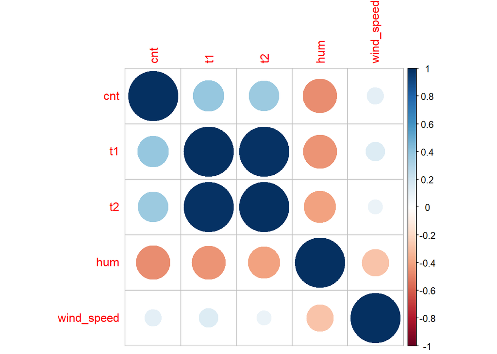

```r
cor_matrix <- cor(select(bike, cnt, t1, t2, hum, wind_speed))
corrplot(cor_matrix)
```

**Data dictionary:**

1. **timestamp** - timestamp field for grouping the data
2. **cnt** - the count of a new bike shares
3. **t1** - real temperature in C
4. **t2** - temperature in C “feels like”
5. **hum** - humidity in percentage
6. **wind_speed** - wind speed in km/h
7. **weather_code** - category of the weather
- 1 = Clear ; mostly clear but have some values with haze/fog/patches of fog/ fog in vicinity
- 2 = scattered clouds / few clouds
- 3 = Broken clouds
- 4 = Cloudy
- 7 = Rain/ light Rain shower/ Light rain
- 10 = rain with thunderstorm
- 26 = snowfall
1. **is_holiday** - boolean field - 1 holiday / 0 non holiday - refers to bank holidays
2. **is_weekend** - boolean field - 1 if the day is weekend / 0 if a working day
3. **season** - category (0-spring; 1-summer; 2-autumn; 3-winter)

## Data Preparation

Data wrangling steps included extracting hour and month from the timestamp for modeling, removing outliers by 3 standard deviation, converting categorical to factors, and normalizing numerical features for clustering. A `day_of_week` variable was added for multiple regression and random forest modeling. The data was split into training (70%), and testing (30%) sets for supervised models.

## Modeling

To address the business questions, multiple modeling approaches were employed, starting with multiple regression for demand forecasting, followed by unsupervised clustering for pattern segmentation, and tree-based methods for interpreting how weather conditions impact rental demand.

### Multiple Regression

```
Call:
lm(formula = cnt ~ ., data = bike)

Residuals:
     Min       1Q   Median       3Q      Max
-2444.69  -271.15   -25.01   246.17  3021.99

Coefficients: (4 not defined because of singularities)
                      Estimate Std. Error t value Pr(>|t|)
(Intercept)           959.4945    53.1688  18.046  < 2e-16 ***
t1                     68.6185     6.1955  11.076  < 2e-16 ***
t2                    -28.5972     5.0035  -5.715 1.11e-08 ***
hum                   -11.3961     0.4689 -24.304  < 2e-16 ***
wind_speed             -8.0029     0.6733 -11.886  < 2e-16 ***
weather_code2          36.9973    11.9164   3.105 0.001908 **
weather_code3          -1.9381    13.0547  -0.148 0.881984
weather_code4         -26.9844    16.7041  -1.615 0.106235
weather_code7        -251.5783    15.8961 -15.826  < 2e-16 ***
weather_code10       -672.3296   145.4484  -4.622 3.82e-06 ***
weather_code26         96.8442    72.8860   1.329 0.183963
is_holiday1          -264.4798    29.6926  -8.907  < 2e-16 ***
is_weekend1          -204.9122    15.5258 -13.198  < 2e-16 ***
season1               -71.5099    22.4293  -3.188 0.001434 **
season2               -43.4686    21.8423  -1.990 0.046595 *
season3               -98.0104    23.6548  -4.143 3.44e-05 ***
hour1                 -68.0503    28.5232  -2.386 0.017054 *
hour2                -118.0198    28.5938  -4.127 3.69e-05 ***
hour3                -145.6443    28.5872  -5.095 3.53e-07 ***
hour4                -149.6230    28.5630  -5.238 1.64e-07 ***
hour5                -105.9568    28.5913  -3.706 0.000211 ***
hour6                 235.3503    28.5903   8.232  < 2e-16 ***
hour7                1197.1299    28.5934  41.867  < 2e-16 ***
hour8                2134.4166    30.6008  69.750  < 2e-16 ***
hour9                1275.2938    28.7127  44.416  < 2e-16 ***
hour10                623.4990    28.9955  21.503  < 2e-16 ***
hour11                656.5476    29.3513  22.369  < 2e-16 ***
hour12                903.4579    29.6071  30.515  < 2e-16 ***
hour13                951.9928    29.8334  31.910  < 2e-16 ***
hour14                902.7950    29.9217  30.172  < 2e-16 ***
hour15                979.5962    29.8312  32.838  < 2e-16 ***
```

[output cut: 16 more lines]

```
month10                88.6501    21.3237   4.157 3.24e-05 ***
month11                     NA         NA      NA       NA
month12               -14.0899    21.4564  -0.657 0.511399
day_of_weekMonday     -29.6956    15.6731  -1.895 0.058151 .
day_of_weekSaturday    25.1068    15.4514   1.625 0.104204
day_of_weekSunday           NA         NA      NA       NA
day_of_weekThursday    11.4688    15.6273   0.734 0.463023
day_of_weekTuesday     10.8560    15.6758   0.693 0.488612
day_of_weekWednesday    9.7508    15.6921   0.621 0.534359
---
Signif. codes:  0 '***' 0.001 '**' 0.01 '*' 0.05 '.' 0.1 ' ' 1

Residual standard error: 541.3 on 16916 degrees of freedom
Multiple R-squared:  0.7056,    Adjusted R-squared:  0.7047
F-statistic:   795 on 51 and 16916 DF,  p-value: < 2.2e-16
```

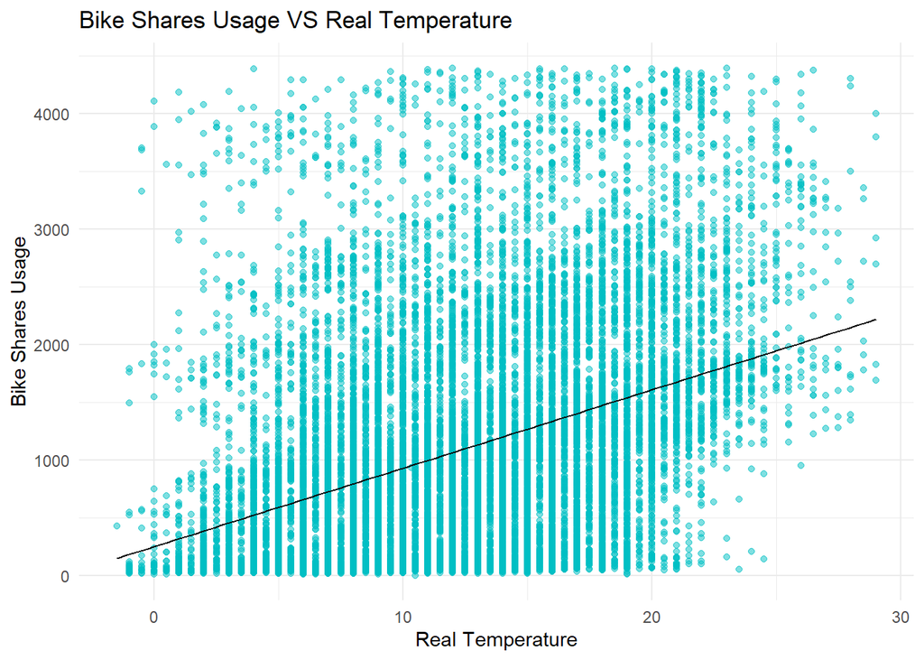

### K-Means

K-Means clustering was applied to segment usage patterns based on environmental and temporal factors.

```r
kmeans_data <- norm_bike %>%
  select(cnt, t1, hum)
```

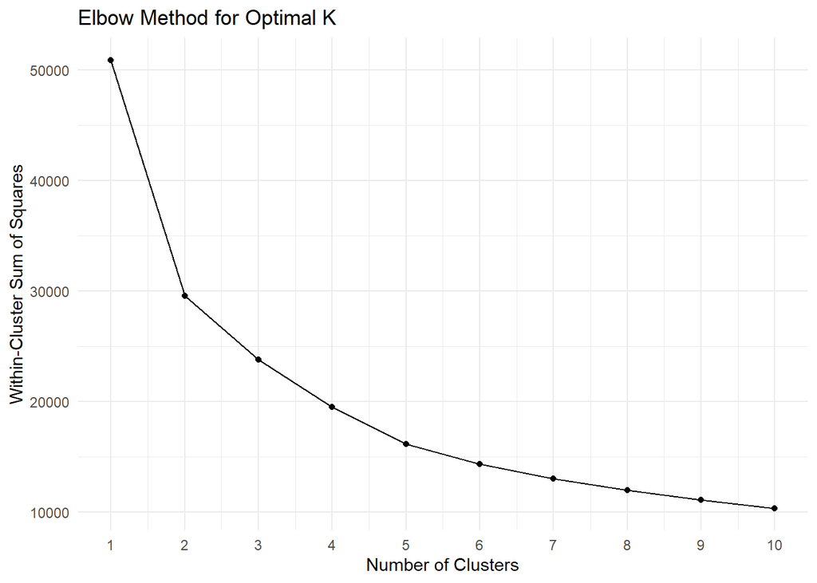

```r
wss <- map_dbl(1:10, function(k){
  kmeans(kmeans_data, centers = k, nstart = 20)$tot.withinss
})

# Visualize the Elbow Plot
tibble(k = 1:10, wss = wss) %>%
  ggplot(aes(x = k, y = wss)) +
  geom_line() +
  geom_point() +
  scale_x_continuous(breaks = 1:10) +
  labs(title = "Elbow Method for Optimal K",
       x = "Number of Clusters", y = "Within-Cluster Sum of Squares") +
  theme_minimal()
```

```r
k <- 4
km <- kmeans(kmeans_data, center = k)

bike_clustered <- bike %>%
  mutate(cluster = factor(km$cluster))

plot_ly(
  data = bike_clustered,
  x = ~t1,      # Real Temperature
  y = ~hum,     # Humidity
  z = ~cnt,     # Count of bikes
  color = ~cluster,
  colors = c("#1f77b4", "#ff7f0e", "#2ca02c", "#099099"),
  type = 'scatter3d',
  mode = 'markers',
  marker = list(size = 4, opacity = 0.7)
) %>%
  layout(
    title = "K-means Clustering of London Bike Data",
    scene = list(
      xaxis = list(title = "Real Temperature (°C)"),
      yaxis = list(title = "Humidity"),
      zaxis = list(title = "Count of Shared Bike")
    )
  )
```

[interactive chart not shown]

### Decision Tree / Random Forest

For more complex relationships and better predictive performance, decision tree and random forest models were developed to forecast demand while providing feature importance insights.

```r
idx <- sample(1:nrow(bike), size = 0.7 * nrow(bike))

train_data <- bike[idx, ]

test_data <- bike[-idx, ]
```

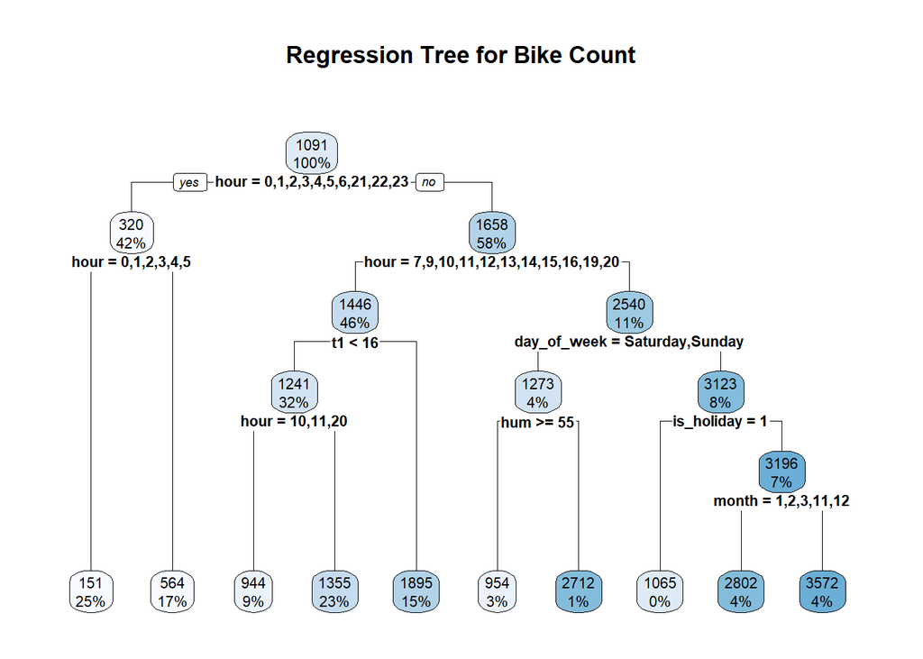

```r
tree_model <- rpart(cnt ~ ., data = train_data, method = "anova")

# Predictions
predictions <- predict(tree_model, test_data)

# Plot tree
rpart.plot(tree_model, cex=0.7, main = "Regression Tree for Bike Count")
```

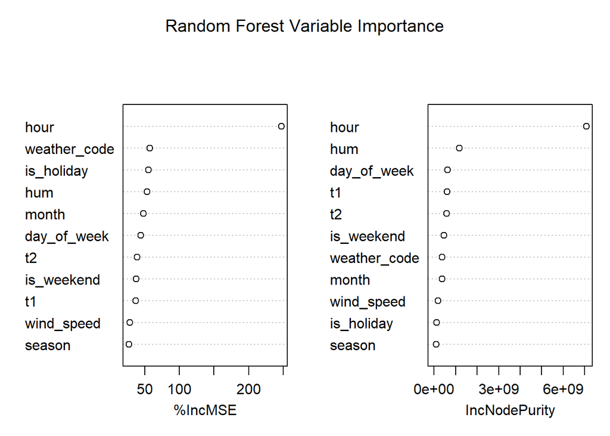

```r
rf_model <- randomForest(
  cnt ~ .,
  data = train_data,
  ntree = 500,
  mtry = 4,
  importance = TRUE
)

rf_preds <- predict(rf_model, test_data)

varImpPlot(rf_model, main = "Random Forest Variable Importance")
```

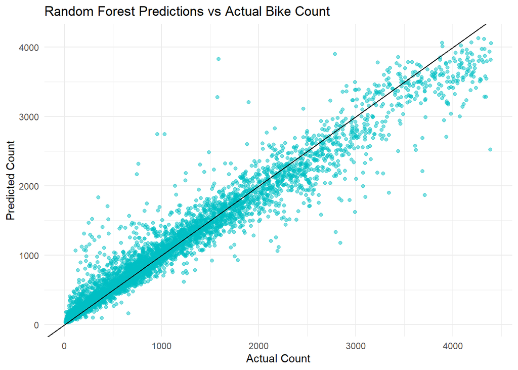

```r
test_data$Predicted <- rf_preds

ggplot(test_data, aes(x = cnt, y = Predicted)) +
  geom_point(alpha = 0.5, color = "#00bfc4") +
  geom_abline(slope = 1, intercept = 0, color = "#090909") +
  labs(
    title = "Random Forest Predictions vs Actual Bike Count",
    x = "Actual Count",
    y = "Predicted Count"
  ) +
  theme_minimal()
```

## Model Evaluation

Model performance was assessed using metrics like R-squared for explained variance and RMSE for prediction error.

### Multiple Regression

The multiple regression model included all variables to predict hourly bike demand. The model achieved an adjusted R-squared of 0.7047, explaining about 70% of the variance in bike counts. While some variables (e.g. `day_of_week`) had higher p-values, removing them did not improve model performance, so the full model was retained.

Weather and seasonal impact:

- Real Temperature (`t1`): Positive effect, with an increase of approximately +68.62 usage per degree.
- Humidity (`hum`): Negative effect. -11.4 usage per 1% increase.
- Wind speed: Negative effect. -8.00 usage per km/h.
- Weather conditions: Poor weather events significantly reduce demand:
  - Rain: -251.58 usage
  - Thunderstorms: -672.33 usage
  - Clear or scattered clouds increase bike usage relative to adverse conditions
- Seasonality: Month and season variables show trends aligned with warmer months having higher usage

### K-Means

```r
km$tot.withinss
```

```
[1] 19514.55
```

These are the classification the four clusters:

**Cluster 1:** Cool & Dry, with high usage

**Cluster 2:** Warm & Humid, with low usage

**Cluster 3:** Hot & Dry, with high usage

**Cluster 4:** Cold & Humid, with low usage.

```r
centroids <- km$centers

centroids_df <- as.data.frame(centroids)
centroids_df$cluster <- 1:k

print(centroids_df)
```

```
         cnt         t1        hum cluster
1  0.8095993 -0.3537037 -0.3163850       1
2 -0.5190328  0.4676402  0.4080944       2
3  1.1302682  1.2601908 -1.3966538       3
4 -0.6877396 -1.0212503  0.6385550       4
```

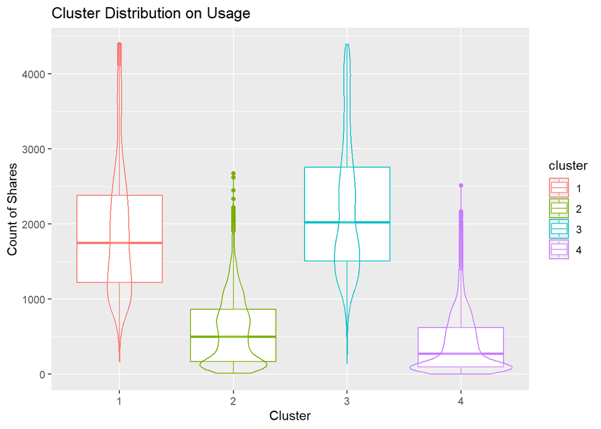

```r
bike_clustered %>%
  ggplot(aes(x = cluster, y = cnt, color = cluster)) +
  geom_boxplot() +
  geom_violin(alpha = 0.2) +
  labs(
    title = "Cluster Distribution on Usage",
    x = "Cluster",
    y = "Count of Shares"
  )
```

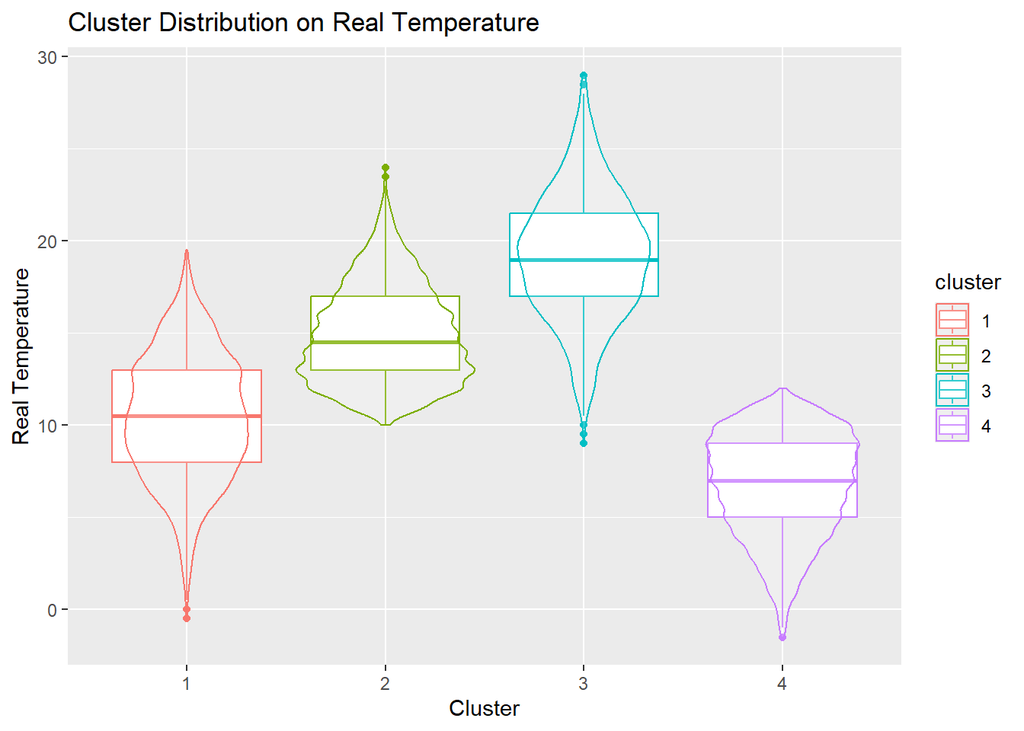

```r
bike_clustered %>%
  ggplot(aes(x = cluster, y = t1, color = cluster)) +
  geom_boxplot() +
  geom_violin(alpha = 0.2) +
  labs(
    title = "Cluster Distribution on Real Temperature",
    x = "Cluster",
    y = "Real Temperature"
  )
```

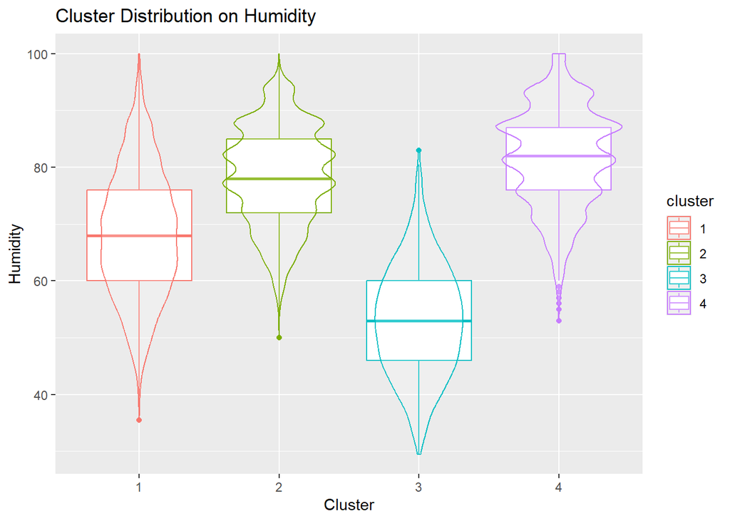

```r
bike_clustered %>%
  ggplot(aes(x = cluster, y = hum, color = cluster)) +
  geom_boxplot() +
  geom_violin(alpha = 0.2) +
  labs(
    title = "Cluster Distribution on Humidity",
    x = "Cluster",
    y = "Humidity"
  )
```

### Decision Tree / Random Forest

#### Decision Tree

The decision tree yielded RMSE=504.8 and R-squared=0.742. It can represent 74.2% of the variance.

```r
# Evaluate the decision tree with RMSE or R-squared
rmse <- sqrt(mean((predictions - test_data$cnt)^2))
rsq <- 1 - sum((predictions - test_data$cnt)^2) / sum((mean(train_data$cnt) - test_data$cnt)^2)

print(paste("RMSE:", round(rmse, 2)))
```

```
[1] "RMSE: 504.8"
```

```r
print(paste("R-squared:", round(rsq, 3)))
```

```
[1] "R-squared: 0.742"
```

#### Random Forest

The random forest give additional insight:

1. Hour still the most influential factor. It ranks highest in both `%IncMSE` and `IncNodePurity`
2. Weather and is holiday are also significant. `weather_code` and `is_holiday` follow as key predictors, suggesting weather conditions and whether a day is a holiday significantly affect bike usage.
3. Humidity plays a moderate role. It ranks moderately high, implying humidity levels influence bike shares.
4. Month and day of week show notable importance, indicating seasonal trends and weekly patterns impact demand.

The random forest improved significantly with ntree=500 and mtry=4, achieving RMSE=233.59 and R-squared=0.945.

```r
# Evaluate with RMSE and R-squared
rmse <- sqrt(mean((rf_preds - test_data$cnt)^2))
r2 <- 1 - sum((rf_preds - test_data$cnt)^2) / sum((test_data$cnt - mean(test_data$cnt))^2)

print(paste("RMSE:", round(rmse, 2)))
```

```
[1] "RMSE: 233.59"
```

```r
print(paste("R-squared:", round(r2, 3)))
```

```
[1] "R-squared: 0.945"
```

## Summary

The analysis reveals that bike demand is positively influenced by higher temperatures and negatively by humidity, wind, holidays, weekends, and adverse weather.

For demand forecasting, hourly bike rental demand can be reliably predicted using the random forest model, which achieves high R-squared (0.945). This enables optimization of bike distribution by anticipating peak periods and low-demand times, as well as scheduling maintenance during off-peak hours to minimize disruptions.

For rental pattern segmentation, distinct usage patterns were identified through K-Means clustering.

- Cluster 1 (Cool & Dry) and Cluster 3 (Hot & Dry) associated with high usage.
- Cluster 2 (Warm & Humid) and Cluster 4 (Cold & Humid) linked to low usage.

#### Key Insights

Actionable insights for optimizing operations and marketing strategies include:

- Use random forest forecasts to move bikes to busy areas during peak hours and good weather. Set up predictive maintenance alerts for times with low usage to reduce downtime and costs.
- Use cluster data to run targeted campaigns. For example, offering discounts to encourage more rides on warm, humid, low-usage days. Introduce dynamic pricing, raise rental rates during busy weekends, holidays, or dry periods, and lower price in bad weather to attract more riders.
- In long-term, client can combine these models into real-time tracking. Set thresholds like 16°C temperature and 55% humidity to trigger automatic price adjustments.

This approach can improve user satisfaction by keeping bikes available, cut operational costs by using resources efficiently, and boost revenue through promotions, supporting sustainable growth for the bike sharing service.

## Reference

1. London bike sharing https://www.kaggle.com/datasets/hmavrodiev/london-bike-sharing-dataset/data